# Compare weighted to unweighted averages

Kyoko Yamaguchi

2022-07-28

This document attemts to 1) calculate some reasonable vector of weights for multiplication during the “extention” portion of the plasma function and 2) compare the root mean squared error (RMSE) between the truth and predictions using the unweighted averages and the weighted averages to see if the weights actually make a difference.

# This is a document to compare weighted to unweighted averages

```r
library(dplyr)
library(pls)
library(plsRcox)
library(survival)
library(plasma)
```

Load data and libraries

```r
# load("C:/Users/Owner/Desktop/svn_oompa_dev/prePlasma/TCGA-ESCA-full.RData")
plasma::loadESCAdata()
```

```r
suspects <- c("A4OM", "A49V", "A8NI")
Outcome[suspects,] # nothing special
```

```
##      patient_id vital_status days_to_death days_to_last_followup Days
## A4OM       a4om         dead          1458                  <NA> 1458
## A49V       a49v        alive          <NA>                   383  383
## A8NI       a8ni         dead           410                  <NA>  410
```

```r
sapply(assemble, function(X) (suspects %in% colnames(X)))
```

```
##      ClinicalBin ClinicalCont  MAF Meth450 miRSeq mRNASeq  RPPA
## [1,]        TRUE         TRUE TRUE    TRUE   TRUE   FALSE FALSE
## [2,]        TRUE         TRUE TRUE    TRUE  FALSE    TRUE  TRUE
## [3,]        TRUE         TRUE TRUE    TRUE  FALSE   FALSE  TRUE
```

```r
sapply(assemble, function(X) {
  S <- suspects[suspects %in% colnames(X)]
  apply(X[, S, drop = FALSE], 2, summary)
})
```

```
## $ClinicalBin
## $ClinicalBin$A4OM
##    Min. 1st Qu.  Median    Mean 3rd Qu.    Max.    NA's
##  0.0000  0.0000  0.0000  0.2553  0.5000  1.0000       6
##
## $ClinicalBin$A49V
##    Min. 1st Qu.  Median    Mean 3rd Qu.    Max.    NA's
##  0.0000  0.0000  0.0000  0.2941  1.0000  1.0000       2
##
## $ClinicalBin$A8NI
##    Min. 1st Qu.  Median    Mean 3rd Qu.    Max.
##  0.0000  0.0000  0.0000  0.2264  0.0000  1.0000
##
##
## $ClinicalCont
##             A4OM      A49V     A8NI
## Min.    -19845.0 -17922.00 -29135.0
## 1st Qu.      0.0  -4443.75      4.0
## Median       0.0     55.50      4.0
## Mean     -3944.4  -4409.50  -5791.8
## 3rd Qu.     54.0     89.75     79.0
## Max.        69.0    173.00     89.0
## NA's         1.0      2.00      1.0
##
## $MAF
##               A4OM       A49V      A8NI
## Min.    0.00000000 0.00000000 0.0000000
## 1st Qu. 0.00000000 0.00000000 0.0000000
## Median  0.00000000 0.00000000 0.0000000
## Mean    0.01238938 0.02123894 0.0619469
## 3rd Qu. 0.00000000 0.00000000 0.0000000
## Max.    1.00000000 1.00000000 1.0000000
## NA's    1.00000000 1.00000000 1.0000000
##
## $Meth450
##                A4OM       A49V       A8NI
## Min.    0.008663996 0.00976101 0.00923999
## 1st Qu. 0.025227400 0.03313268 0.03567959
## Median  0.061566294 0.27009366 0.15891598
## Mean    0.230328657 0.43926806 0.32761651
```

[output cut: 15 more lines]

```
## Min.     3.321928
## 1st Qu.  5.381714
## Median   7.258732
## Mean     7.312161
## 3rd Qu.  9.048671
## Max.    16.072263
##
## $RPPA
##                A49V        A8NI
## Min.    -2.62818896 -1.32457907
## 1st Qu. -0.22129888 -0.18007237
## Median   0.00000000  0.00000000
## Mean    -0.01849452  0.03545943
## 3rd Qu.  0.17037930  0.24346900
## Max.     2.07058294  1.37678735
```

```r
ls()
```

```
## [1] "assemble" "m450info" "Outcome"  "suspects"
```

We have minor missing data in the ClinicalBin data set for two suspect samples (A4OM, A49V). We also have completely missing data in some of the omics data sets. Other than that, things look fine.

# Proof of concept for one iteration only

## Dataset shrinking

What if we shrink to some percentage of its original size? Output the names of the datasets that are going to be shrunken:

```r
set.seed(123)
namesub<- c("MAF", "Meth450", "miRSeq", "mRNASeq")
```

```r
assemble_truth <- assemble[ which(names(assemble) %in% namesub) ]
```

assemble_truth contains the original unmodified data. The model arising from assemble represents our “ground truth” model.

```r
lapply(assemble_truth, dim)
```

```
## $MAF
## [1] 566 184
##
## $Meth450
## [1] 1454  185
##
## $miRSeq
## [1] 926 166
##
## $mRNASeq
## [1] 2520  157
```

```r
MO_truth <- prepareMultiOmics(assemble_truth, Outcome)
suppressWarnings( firstPass_truth <- fitCoxModels(MO_truth, timevar = "Days",
                          eventvar = "vital_status", eventvalue = "dead") )
```

[output not shown]

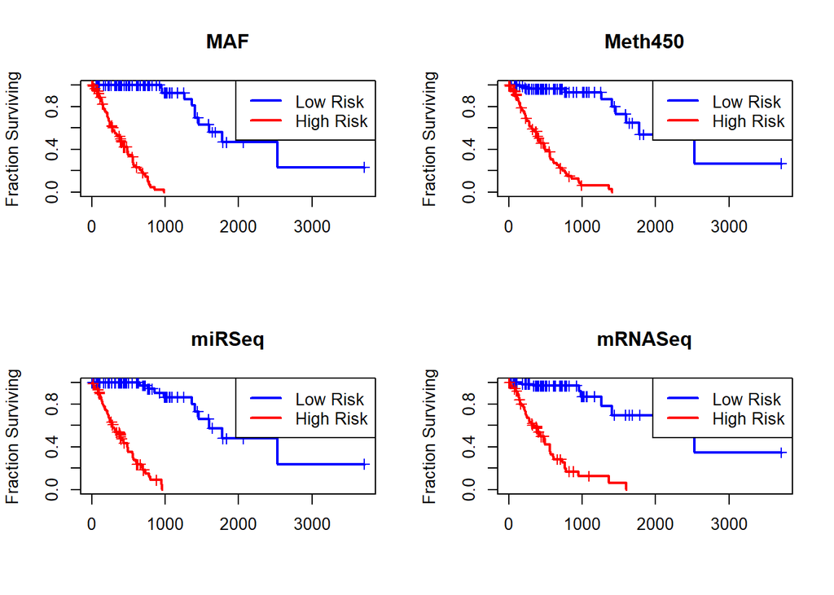

```r
plot(firstPass_truth)
```

```r
lapply(namesub, function(ds) {
  A <- firstPass_truth@models[[ds]]
  A@Xout[suspects,]
})
```

```
## [[1]]
##      patient_id vital_status days_to_death days_to_last_followup Days     Risk
## A4OM       a4om         dead          1458                  <NA> 1458 1.008755
## A49V       a49v        alive          <NA>                   383  383 1.767338
## A8NI       a8ni         dead           410                  <NA>  410 5.411184
##      Split
## A4OM     0
## A49V     0
## A8NI     1
##
## [[2]]
##      patient_id vital_status days_to_death days_to_last_followup Days
## A4OM       a4om         dead          1458                  <NA> 1458
## A49V       a49v        alive          <NA>                   383  383
## A8NI       a8ni         dead           410                  <NA>  410
##            Risk Split
## A4OM -2.1248534     0
## A49V -1.3658143     0
## A8NI  0.7782229     1
##
## [[3]]
##      patient_id vital_status days_to_death days_to_last_followup Days     Risk
## A4OM       a4om         dead          1458                  <NA> 1458 -2.37125
## NA         <NA>         <NA>          <NA>                  <NA>   NA       NA
## NA.1       <NA>         <NA>          <NA>                  <NA>   NA       NA
##      Split
## A4OM     0
## NA      NA
## NA.1    NA
##
## [[4]]
##      patient_id vital_status days_to_death days_to_last_followup Days      Risk
## NA         <NA>         <NA>          <NA>                  <NA>   NA        NA
## A49V       a49v        alive          <NA>                   383  383 -1.828187
## NA.1       <NA>         <NA>          <NA>                  <NA>   NA        NA
##      Split
## NA      NA
## A49V     0
## NA.1    NA
```

When we look into the single-omic models, we see the expected results. Specifically, we get reasonable values when the sample is in the omics data set, and get NA’s otherwise. **WAIT!** Shouldn’t it be the case that all the names are present in all the data sets?

```r
sapply(namesub, function(ds) {
  A <- firstPass_truth@models[[ds]]
  dim(A@Xout)
})
```

```
##      MAF Meth450 miRSeq mRNASeq
## [1,] 184     185    165     157
## [2,]   7       7      7       7
```

Never mind; these do not get automatically expanded to the full sample set. So, everything is as it should be so far.

```r
pl_truth <- plasma(MO_truth, firstPass_truth)
# plot(pl_truth, legloc = "topright", main = "True Data")
```

```r
mp <- pl_truth@meanPredictions
mp[suspects,]
```

```
##           MAF1     MAF2       MAF3       MAF4  Meth4501 Meth4502   Meth4503
## A4OM -0.217598 3.844958 0.23365698 -0.1533663 -9.039424 8.546924 -0.1853033
## A49V -0.206872 2.029983 0.05596606 -0.1817994 -5.025889 5.994110 -0.2962981
## A8NI       NaN      NaN        NaN        NaN       NaN      NaN        NaN
##        Meth4504    miRSeq1    miRSeq2   miRSeq3    miRSeq4   mRNASeq1  mRNASeq2
## A4OM -1.0356523  1.3150243 -2.9832526 3.2625183 -1.2508817 -10.764155 3.8091112
## A49V -0.0393493 -0.1764494 -0.5939904 0.3473436 -0.1140371  -5.426525 0.5133862
## A8NI        NaN        NaN        NaN       NaN        NaN        NaN       NaN
##        mRNASeq3  mRNASeq4
## A4OM  1.5904292 -7.852136
## A49V -0.4499664  4.018108
## A8NI        NaN       NaN
```

One of the “suspects” produces NaN’s across the board. Let’s see if we can figure out where that comes from.

```r
modlist <- pl_truth@compModels
for (N in names(modlist)) {
  print(N)
  X <- modlist[[N]]
  Y <- X$allPred
  S <- suspects[suspects %in% rownames(Y)]
  print(Y[S, , drop = FALSE], 2)
}
```

```
## [1] "MAF"
##      MAF1 MAF2 MAF3 MAF4 Meth4501 Meth4502 Meth4503 Meth4504 miRSeq1 miRSeq2
## A4OM   NA   NA   NA   NA       NA       NA       NA       NA      NA      NA
## A49V   NA   NA   NA   NA       NA       NA       NA       NA      NA      NA
## A8NI   NA   NA   NA   NA       NA       NA       NA       NA      NA      NA
##      miRSeq3 miRSeq4 mRNASeq1 mRNASeq2 mRNASeq3 mRNASeq4
## A4OM      NA      NA       NA       NA       NA       NA
## A49V      NA      NA       NA       NA       NA       NA
## A8NI      NA      NA       NA       NA       NA       NA
## [1] "Meth450"
##      MAF1 MAF2 MAF3 MAF4 Meth4501 Meth4502 Meth4503 Meth4504 miRSeq1 miRSeq2
## A4OM   NA   NA   NA   NA       NA       NA       NA       NA      NA      NA
## A49V   NA   NA   NA   NA       NA       NA       NA       NA      NA      NA
## A8NI   NA   NA   NA   NA       NA       NA       NA       NA      NA      NA
##      miRSeq3 miRSeq4 mRNASeq1 mRNASeq2 mRNASeq3 mRNASeq4
## A4OM      NA      NA       NA       NA       NA       NA
## A49V      NA      NA       NA       NA       NA       NA
## A8NI      NA      NA       NA       NA       NA       NA
## [1] "miRSeq"
##       MAF1 MAF2 MAF3  MAF4 Meth4501 Meth4502 Meth4503 Meth4504 miRSeq1 miRSeq2
## A4OM -0.22  3.8 0.23 -0.15       -9      8.5    -0.19       -1     1.3      -3
##      miRSeq3 miRSeq4 mRNASeq1 mRNASeq2 mRNASeq3 mRNASeq4
## A4OM     3.3    -1.3      -11      3.8      1.6     -7.9
## [1] "mRNASeq"
##       MAF1 MAF2  MAF3  MAF4 Meth4501 Meth4502 Meth4503 Meth4504 miRSeq1 miRSeq2
## A49V -0.21    2 0.056 -0.18       -5        6     -0.3   -0.039   -0.18   -0.59
##      miRSeq3 miRSeq4 mRNASeq1 mRNASeq2 mRNASeq3 mRNASeq4
## A49V    0.35   -0.11     -5.4     0.51    -0.45        4
```

Well, it seems that we have no data for suspect `A8NI`. That makes it hard to pool the prediction data. But why do we get NA’s from the MAF and Meth450 data sets, even though we know most of the data is available there?

```r
A <- modlist$MAF$allPred
awful <- apply(A, 1, function(x) all(is.na(x)))

pick <- apply(assemble$MAF, 2, function(x) any(is.na(x)))
all(names(pick) == names(awful))
```

```
## [1] FALSE
```

```r
summary(awful)
```

```
##    Mode   FALSE    TRUE
## logical     124      60
```

```r
awful <- awful[names(pick)]
table(awful, pick)
```

```
##        pick
## awful   FALSE TRUE
##   FALSE   124    0
##   TRUE      0   60
```

```r
AMAF <- assemble$MAF
amed <- apply(AMAF, 1, median, na.rm = TRUE)
summary(amed)
```

```
##     Min.  1st Qu.   Median     Mean  3rd Qu.     Max.
## 0.000000 0.000000 0.000000 0.001767 0.000000 1.000000
```

```r
for (i in 1:nrow(AMAF)) {
  X <- AMAF[i,]
  X[is.na(X)] <- amed[i]
  AMAF[i,] <- X
}
any(is.na(AMAF))
```

```
## [1] FALSE
```

```r
AMeth <- assemble$Meth450
amed <- apply(AMeth, 1, median, na.rm = TRUE)
summary(amed)
```

```
##    Min. 1st Qu.  Median    Mean 3rd Qu.    Max.
## 0.01243 0.09693 0.29645 0.31613 0.48896 0.96635
```

```r
for (i in 1:nrow(AMeth)) {
  X <- AMeth[i,]
  X[is.na(X)] <- amed[i]
  AMeth[i,] <- X
}
any(is.na(AMeth))
```

```
## [1] FALSE
```

```r
imputed <- assemble[which(names(assemble) %in% namesub) ]
imputed$MAF <- AMAF
imputed$Meth450 <- AMeth

MO_imp <- prepareMultiOmics(imputed, Outcome)
suppressWarnings( firstPass_imp <- fitCoxModels(MO_imp, timevar = "Days",
                          eventvar = "vital_status", eventvalue = "dead") )
```

[output not shown]

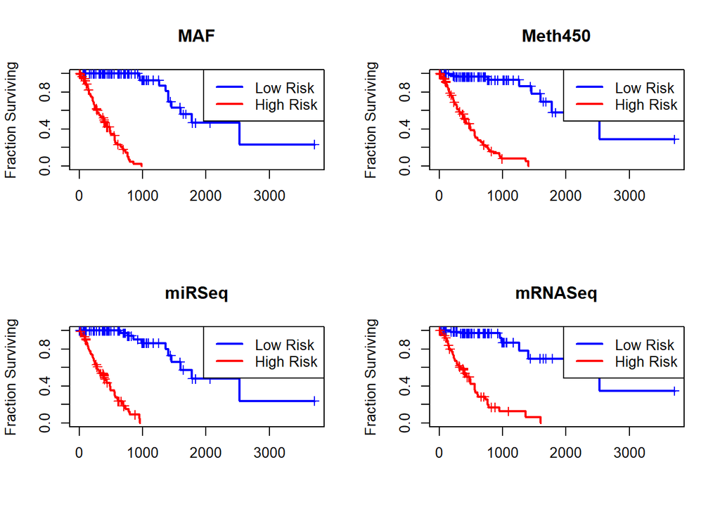

```r
plot(firstPass_imp)
```

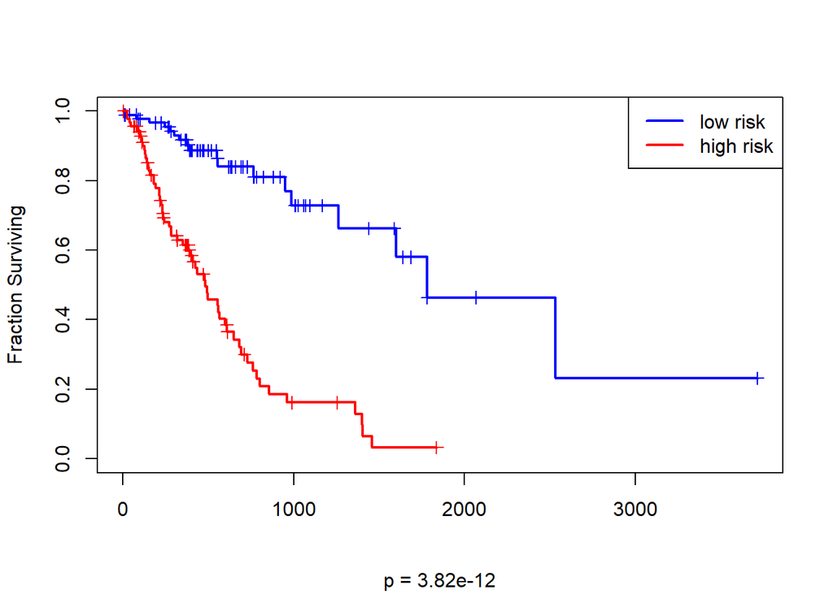

```r
pl_imp <- plasma(MO_imp, firstPass_imp)
plot(pl_imp)
```

```r
mp <- pl_imp@meanPredictions
mp[suspects,]
```

```
##             MAF1      MAF2        MAF3        MAF4  Meth4501  Meth4502
## A4OM -0.25530929 2.1028929  0.22163308 -0.12102499 -9.044196  3.191147
## A49V -0.21709859 0.4306066  0.14820403 -0.10110801 -8.696284 -2.875246
## A8NI  0.07618884 0.7248079 -0.06990933 -0.01974584  4.804748  6.656882
##       Meth4503    Meth4504    miRSeq1    miRSeq2    miRSeq3    miRSeq4
## A4OM  0.327316 -0.40364223  0.2309920 -1.2198427  1.7985054 -0.9581703
## A49V  1.538960  0.02080099 -1.3619823  0.4677598  0.5074175 -0.3988452
## A8NI -1.922531 -0.13066161  0.8430643 -0.4838626 -0.1866366  0.1531950
##        mRNASeq1  mRNASeq2   mRNASeq3   mRNASeq4
## A4OM  -9.461953 2.0281618  0.6380581 -2.3614657
## A49V -10.894612 0.1905364 -0.5012063  0.6674913
## A8NI   6.801244 0.4661093  0.4300018  0.8528500
```